# BIO-MATE: A biological ocean data reformatting effort

Kimberlee Baldry $^{*,a}$ Robert Johnson $^{b}$ Peter G. Strutton [$^{a}$ Philip W. Boyd [$^{a}$](https://orcid.org/0000-0001-7850-1911)](https://orcid.org/0000-0002-2395-9471)

$*$: Corresponding author. E-mail: kimberlee.baldry@utas.edu.au $a$: Institute for Marine and Antarctic Studies, University of Tasmania, Hobart, Australia $b$: Bureau National Operations Centre, Bureau of Meteorology, Hobart, Australia

Abstract

Biological ocean data collected from ships find reuse within aggregations of historical data. These data are heavily relied upon to document long term change, validate satellite algorithms for ocean biology and are useful in assessing the performance of autonomous platforms and bio-physical models. There is a need to combine subsurface biological and physical data into one aggregate data product to support reproducible research. This is motivated by an era of increased use of biogeochemical ocean models and autonomous observations. Existing aggregate products are dissimilar in source data, have largely been isolated to the surface ocean and most omit physical data. These products cannot easily be used to explore subsurface bio-physical relationships. We present the first version of a biological ocean data reformatting effort (BIO-MATE). BIO-MATE is R software that reformats and aggregates openly sourced published datasets from oceanographic voyages (https://gitlab.com/KBaldry/BIO-MATE). Biological and physical data from underway sensors, profiling sensors, pigments analysis and particulate organic carbon analysis are stored in BIO-MATE.

# Background & Summary

Marine phytoplankton blooms support ocean food-webs and influence global climate through the biological carbon pump (1; 2: 3). Ocean physics and other environmental drivers control the timing, magnitude and extent of phytoplankton blooms through complex bio-physical relationships (4; 5; 6; 7). To study these bio-physical relationships integrated data structures that link biological and physical ocean data are needed. Ship-based data is the gold-standard for accurate biological oceanographic measurements (8). These data are often published separately to physical ocean data, stored across different repositories and in multiple formats. This makes it difficult and time-consuming to aggregate and link biological and physical data. The described data product attempts to make this task easier.

The biological ocean data reformatting effort (BIO-MATE) works to link existing, open-access biological and physical datasets across oceanographic voyages and promote their re-use. This has been done by developing R based software that not only reformats published datasets, but also cross-references between biological and physical data (https://github.com/KimBaldry/BIOMATE-Rpackage). A final aggregate data product allows users to easily access, manipulate and cite published ship-based datasets of different dimensions for multiple applications.

The BIO-MATE aggregate data product can be accessed via the Australian Ocean Data Network (https://portal.aodn.org.au/). The aggregation includes data collected from shipboard underway sensors, profiling sensors mounted on sampling rosettes, lab analysis for phytoplankton pigments and lab analysis for particulate organic carbon (POC). These data are stored as four data streams, cross-referenced by unique expedition codes (EXPOCODE) and profiling station identifications (CTD_ID). An additional data stream contains supporting information for the data product including a list of oceanographic voyages, investigator contact information and data citations for reformatted datasets. We have also included an aggregated data table for biological data. Users are required to refer to supporting data and cite all data products accessed through BIO-MATE, as well as the BIO-MATE data product itself. We consulted the distribution licenses of all data sources to ensure that with this condition data is re-used lawfully.

In the future BIO-MATE can be extended to include new cruises, new biological variables and an online interface to facilitate data submissions. The product is formatted to facilitate a global database and for the addition of new biological parameters (e.g. microscopic abundances) in future versions. We initially restricted this version of BIO-MATE to the Southern Ocean as it is historically underrepresented in previous aggregations of biological data: 9, 10, 11, 12, MAREDAT (13) and NoMAD/SeaBASS (14; 15; https://seabass.gsfc.nasa.gov/). This has led to a lack of understanding (12) and poor performance of models due to the unique biogeochemistry of the vast region (10; 16).

We recognise the massive effort in producing the thousands of data records within this data product. This includes the investigators and data officers who have spent countless hours in ship-time, project organisation, grant writing, laboratory analysis, post-processing data and report writing. Oceanographic data are often collected with regional studies in mind, but their value increases with publication and re-use. We encourage all investigators to publish their data for re-use through data products like BIO-MATE.

# Methods

#### *Published datasets in BIO-MATE*

Data records from the pigment data stream were first identified within data reprositories that host biological data (November 2019). Pigment data records were identified using the search term “chlorophyll” and a latitude bound of 30 $^\circ$S to 90 $^\circ$S from PANGAEA (https://www.pangaea.de/), SeaBASS (https://seabass.gsfc.nasa.gov/), the Australian Ocean Data Network (AODN, https://portal.aodn.org.au/), GLODAP (https://www.glodap.info/), the Palmer Long Term Ecological Record (Pal-LTER, https://pal.lternet.edu/data), the Biological and Chemical Oceanography Data Management Office (BCO-DMO, https://www.bco-dmo.org/data), the CSIRO Marlin Data Trawler (Marlin, https://www.cmar.csiro.au/data/trawler/) and the Australian Antarctic Data Center (AADC, https://data.aad.gov.au/).

The voyage records were then used to perform a wider search for published data records for the remaining data streams. All published datasets within the first version of BIO-MATE were openly sourced throgh data records within CCHDO (https://cchdo.ucsd.edu/), MGDS (https://www.marine-geo.org/), PANGEA, SeaBASS, AODN, GLODAP, Pal-LTER, BCO-DMO, Marlin and the AADC. If a data record was not found within these repositories, a final search using the Google search engine was performed using keywords (i.e. ship name, synonyms for voyages, year, “underway”/ “CTD”, “chlorophyll”, ”POC”, “cruise report” and “data”) to determine its absence.

#### *Semi-automated BIO-MATE workflow for reformatting datasets*

##### *Download of published datasets*

Published datasets were manually downloaded from open source repositories and stored locally in accordance with data policies. Some manual reformatting of a small portion of downloaded data had to be performed on old datasets, prior to the application of reformatting scripts, due to formatting irregularities. Downloaded data files, and their ammendments, used to create the BIO-MATE data product are not published within BIO-MATE, but are available upon request to the corresponding author.

##### *Splitting large datasets with BIO-MATE software*

The BIO-MATE R software requires each file to only contain observations from a single voyage. Further, the profiling sensor data stream requires each file to only contain observations from a single profiling cast, held within a descrete directory for each voyage.

##### *Dataset citation with BibTEX files*

Citation information is included within the BIO-MATE software and data product, for published datasets ingested into the BIO-MATE aggregate data product, laboratory analysis methodologies (for the PIG and POC data streams) and data repositories through which published datasets were accessed. Each citation was recorded as a BibTEX entry that allows citations to imported and managed within programs including EndNote, R and LaTEX. Each BibTEX entry has a tag that is referenced within processing metadata. This tag is used to link citations to their corresponding data records when datasets are ingested in the BIO-MATE software. Citation information is then printed within the header information in reformatted files. Where possible BibTEX entries were sourced from data repositories. If BibTEX entries were not found, they were created manually.

##### *Reformatting and linking data streams with BIO-MATE R software*

Once datasets were stored in the appropriate format, processing metadata was entered and citation information collated, the BIO-MATE R software was run to reformat data files. Each data stream has its own reformatting function within the BIO-MATE R software (UWY_to_WHPE, PROF_to_WHPE, PIG_to_WHPE, POC_to_WHPE). The software arranges reformatted files into four data stream within local directories that include, for each EXPOCODE, 1) one WHP-Exchange file for underway sensors 2) a WHP-exchange file per profiling station for profiling sensors 3) one WHP-Exchange file for pigment measurements measured by a particular method and 4) one WHP-Exchange file for POC measurements measured by a particular method. Physical (underway sensor and profiling sensor) data streams were first reformatted before pigment data streams, as required by the BIO-MATE software.

The four Bio-MATE R software functions reformats data files to the WHP-Exchange format as described in (https://exchange-format.readthedocs.io/en/latest/index.html), using the original data files, processing metadata and citation information as input. The WHP-Exchange file format keeps metadata as multiple header names which is followed by a data table using pre-described headers. Pigment records were alternatively named according to the MAREDAT data product to conform with community expectations.

The PIG_to_WHPE and POC_to_WHPE functions in BIO-MATE contain a biological-physical matching algorithm. The algrithm links biological data in the respective pigment and POC data streams to the physical data located within the profiling sensor and underway sensor data streams. Bio-logical data records are the given a profiling sensor identification tag (CTD_ID) and an underway sensor identification tag (UWY_ID) if matched to physical data within BIO-MATE.

#### *Quality assurance*

The initial integrity of these data records lies with the Principal Investigators of the published data record. As a result, reformatted data has varying levels of quality control and post-processing. We have included cruise report citations within our product to aid in further data quality assurance efforts. Future versions of the product may include more detailed quality assurance assessments.

# Data Records

#### *Supporting data*

Supporting data is included within the BIO-MATE aggregate data product to support the correct citation of data and guide user access to data. This data includes 1. a BibTEX file, that contains information to reference all BIO-MATE data records 2. a index table indicating data availability and citation tags against data records listed by EXPOCODE, datastream, method and source, 3. a records table for all data repositories from which BIO-MATE data was sourced from and 4. a records table for all pigment and POC analysis methods used in BIO-MATE data.

# Technical Validation

We validate the quality of the BIO-MATE data compilation and confirm that data was compiled correctly through the BIOMATE software, by displaying a number of key data distributions and trends. This validation does not confirm the quality of individual data points, in which the authors have placed no additional quality assurance to the published datasets. The quality assurance required of physical and biological ocean data varies according to application, and is up to the user to confirm the data is suitable for their application. For example, when assessing basin-scale trends a lower level of quality assurance is required, compared to when validating or training satellite algorithms or ocean models. Future versions of BIO-MATE could inmplement quality assurance metrics.

# Usage Notes

#### *Contributing to BIO-MATE software development*

It is recommended that changes to BIO-MATE software be made within the GitHub environment. Contributors can fork the existing repository (https://github.com/KimBaldry/BIOMATE-Rpackage) and make changes directly to the source code. Once changes are made, they can be directed back to the BIOMATE-Rpackage repository and released as an updated version of the BIO-MATE software. If the BIO-MATE source code is to be significantly developed, we suggest that the corresponding author is contacted and a hand-over of the software is negotiated. We encourage the addition of new data streams to BIO-MATE, the expansion of BIO-MATE capabilities, the addition of quality assurances and increases in software efficiency.

#### *Contributing data to BIO-MATE*

Users can submit published biological ocean data to BIO-MATE using the R shiny app BIO-SHARE (@(fig:user_guide)). Once data is submitted it can be downloaded by the user and is automatically submitted to the BIO-MATE GitHub repository for future addition into the product. We ask that all data submitted to BIO-MATE is published elsewhere and that users enter an accurate citation for the data they are submitting.

For large data submissions, users can create their own workflows using the BIO-MATE R package to reformat data and information (@(fig:user_guide)). Once data has been reformatted, it can be submitted to the corresponding author via GitHub or direct communication.

Currently, BIO-MATE only supports data files stored in text-delimited formats, with structured headers and columns in a data table, and NetCDF format. The user is required to enter in some metadata to inform the software on input formats.

#### *Recommended use in Data Analyses*

We encourage the use of the data aggregate product as a new integrated database of biological and physical data. Data files from selected voyages can be identified using unique EXPOCODES and CTD_IDs. This makes it easy to use multiple data streams in analysis, by indexing files across these EXPOCODES. Alternatively, the selection tool on the IMAS repository helps users to select voyages using spatial bounds.

Limited quality assurance has been performed on the BIO-MATE aggregate product and is highly variable across published datasets. It is recommended that users process data using their own quality assurance procedures, suitable for their unique data analysis. This allows a range of users to benefit from the BIO-MATE aggregate product and ensures data remains to the standard it was published at.

# Code Availablility

All data processing was performed in R software (Version 1.1.423). The BIO-MATE R software is freely available (https://github.com/KimBaldry/BIOMATE-Rpackage). The semi-automated workflow and accompanying processing data used to construct the data product, along with the code used to create the data decrioptor is freely accessible via Git Hub (https://github.com/KBaldry/BIO-MATE).

# Aknowledgements

This research was supported under Australian Research Council's Special Research Initiative for Antarctic Gateway Partnership (Project ID SR140300001) and a 2019 Fellowship from the Scientififc Committee of Antarctic Research. It was also partially supported by Geoscience Australia, in the form of funded study leave. Data included in the data product was made available by the following data repositories; PANGEAE, AODN, SeaBASS, CCHDO, AADC. Records of data access dates, source addresses and digital object identifiers are recorded as metadata within the product, alongside appropriate data citations. We acknowledge the enormous community effort undertaken in the collection, analysis and publication of this data and thank principle investigators for publishing their data in open access repositories.

# Author Contributions

KB designed the data product, performed the data aggregation and wrote the manuscript. RJ contributed to the data product design and manuscript edits.

# Competing Interests

The authors of this manuscript declare no conflicts of interest.

# Figures

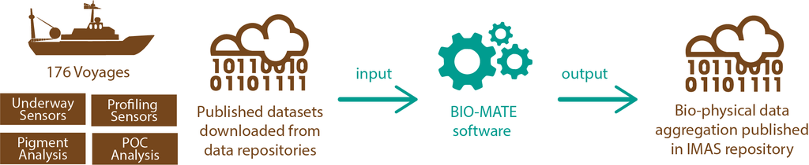

The BIO-MATE concept for creating a consistent data compilation from existing ship-based oceanographic data

[figure not shown]

The origins of the data contained within the different BIO-MATE data streams.

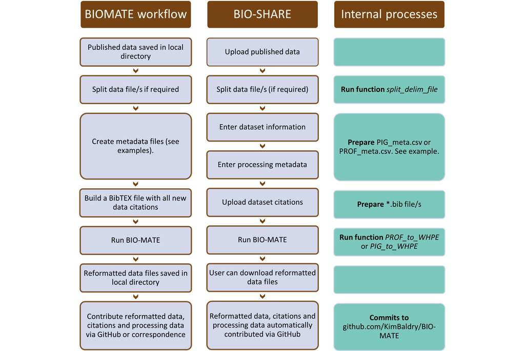

A schematic demonstrating the BIO-MATE workflow and how it is implemented in BIO-SHARE

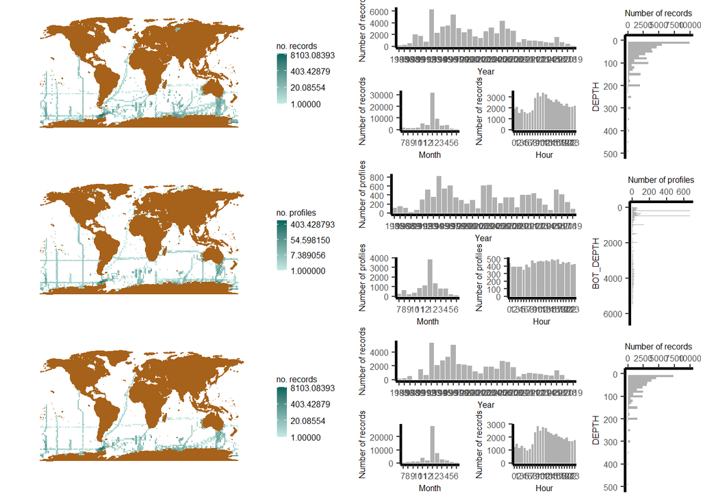

The spatiotemporal distribution of different data streams and bio-physical matches in the BIOMATE data compilation

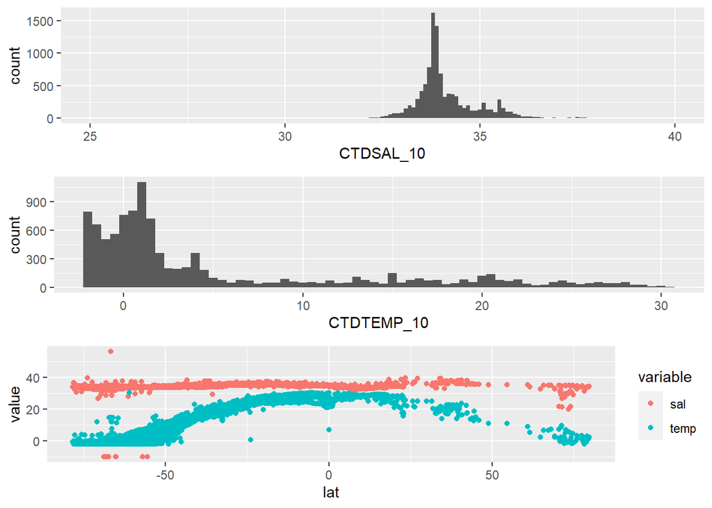

The distribution of temperature and salinity data measured at 10m by profiling sensors in the BIOMATE data compilation

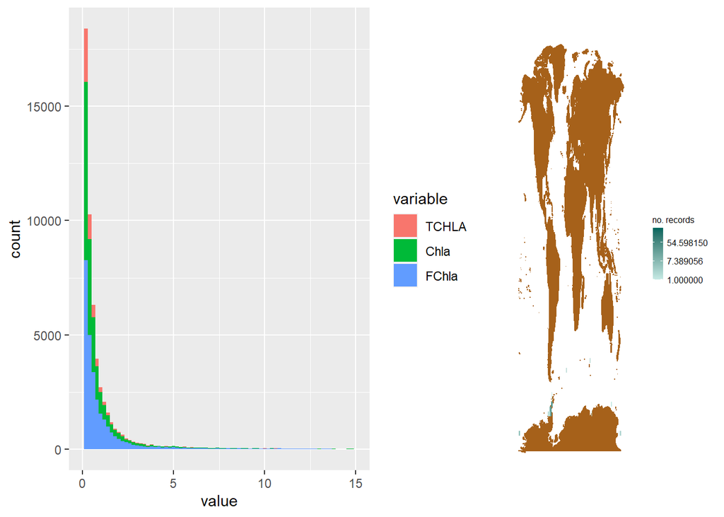

The (a) distribution of Chla, TCHLA and FCHLA in the BIO-MATE data compilation and (b) the location of high Chla, TCHLA and FCHLA measurements.

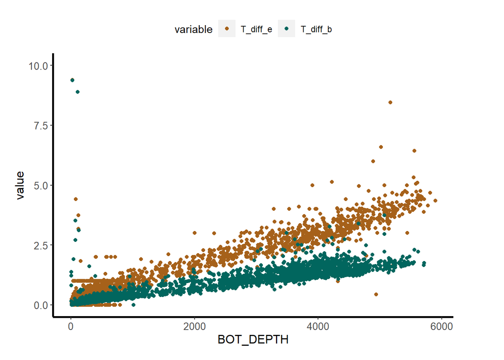

The length of time past at the bottom and end possitions of a profiling sesnor cast versus the bottom depth of the cast

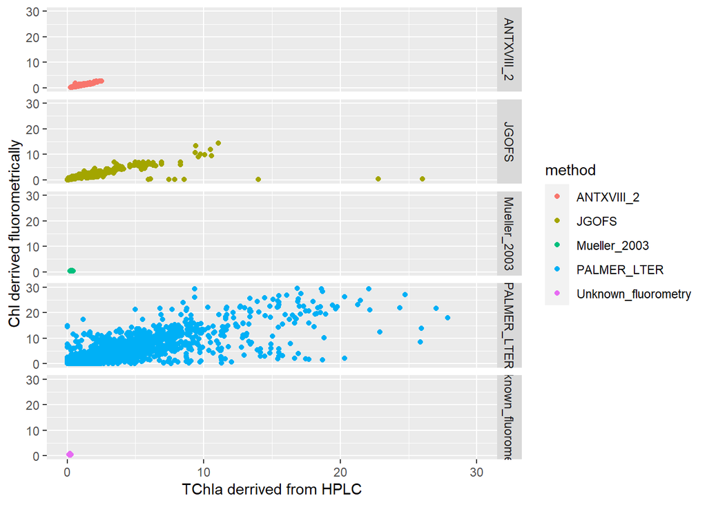

A comparison of fluorometrically derrived chlorophyll (Chl) methods against total chlorophyll-a (TChla) derrived from HPLC measurments

# Tables

| Processing metadata variable | Data stream/s | Description | Input Guide |
| --- | --- | --- | --- |
| **File format information** |  |  |  |
| file_type | all | The format of the file/s. | text delim or netcdf |
| path | all | A path to where the file/s is stored. | A pathname that is R compatible |
| extention | all | The extension of the file/s. | text delim or netcdf |
| delim | all | Only fill if rectangular text-delimited file/s. | rect |
| header_sep | all | A separator used in headers of the file. Headers often store location data in profiling datasets and need extraction. Can be left empty. | colon, comma, dash, equals, space |
| missing_value | all | The value or character used to indicate a missing value. | value |
| not_detected | PIG, POC | The value or character used to indicate a variable was not detected in analysis. | value |
| **Data aquisition information** |  |  |  |
| EXPOCODE | all | The EXPOCODE of the voyage associated with the data. | 12-digit code |
| source | all | The data repository the data files were sourced from. | The short name of the data repository used within BIO-MATE. See https://github.com/KimBaldry/BIO-MATE/product_data/supporting_information/BIOMATE_SOURCES.txt. |
| PI | all | The principle investigator/s responsible for the published dataset. | Names sepparated by a dash |
| Institution | all | The institution/s who collected the data. | Names sepparated by a dash |
| contact | all | A contact for the published dataset. | E-mail address |
| citation | all | The BIO-MATE citation tag/s used to reference a BibTEX entry for the published dataset. | A BIO-MATE citation tag |
| analysis_type | PIG, POC | The type of analysis used on water samples for the published dataset. | A code to reference an analysis type. See https://github.com/KimBaldry/BIO-MATE/product_data/supporting_information/BIOMATE_METHODS.txt |
| Method | PIG, POC | The method used to analyse water samples for the published dataset. | A code to reference a method. See https://github.com/KimBaldry/BIO-MATE/product_data/supporting_information/BIOMATE_METHODS.txt |
| **Location data information** |  |  |  |
| TZ | all | The time zone for date and time information. | Time zone code |
| STNNBR | all | The name of the variable for the station number of the profiling staation. | Text. If recorded in header use header-[variable]. |
| CASTNO | all | The name of the variable for the cast number at the profiling station. | Text. If recorded in header use header-[variable]. |
| DATE | PROF | The name of the variable for the date of the profiling cast. | Text. If recorded in header use header-[variable]. |
| DATE_analyser | PIG, POC | The name of the variable for date of observation recorded by the analyser. | Text. If recorded in header use header-[variable]. |
| DATE_format | PROF | Format for DATE. | A format string code. See strptime in R for codes. |
| DATE_analyser_format | PIG, POC | Format for DATE_analyser. | A format string code. See strptime in R for codes. |
| TIME_s | PROF | The name of the variable for time at the start of teh profiling cast. | Text. If recorded in header use header-[variable]. |
| TIME_b | PROF | The name of the variable for time at the bottom of the profiling cast. | Text. If recorded in header use header-[variable]. |
| TIME_e | PROF | The name of the variable for time at the end of the profiling cast. | Text. If recorded in header use header-[variable]. |
| TIME_analyser | PIG, POC | The name of the variable for time of observation recorded by the analyser. If recorded in header use header-[variable]. | Text |
| TIME_format | PROF | Format for TIME. | A format string code. See strptime in R for codes. |

[output cut: 80 more lines]

| Number of voyages | Number of Records | Unique samples (no replicates) | Unique samples in lat and lon (not depth) | Bio-physical matches | HPLC and fluorometry matches | Number of HPLC records | Number of Fluorometry records | Matches with CTDFLUOR records | Matches with CTDBBP700 records | Matches with CTDBEAMCP records |
| --- | --- | --- | --- | --- | --- | --- | --- | --- | --- | --- |
| **All pigment records** |  |  |  |  |  |  |  |  |  |  |
| 174 | 65866 | 62049 | 15001 | 45950 | 3008 | 26885 | 38717 | 21887 | 2829 | 5925 |
| **Subsurface profile records (>4 depth samples above 75 m)** |  |  |  |  |  |  |  |  |  |  |
| 115 | 45114 | 42881 | 4648 | 34556 | 1544 | 14934 | 30089 | 16363 | 2460 | 4668 |
| **Surface records (<10 m)** |  |  |  |  |  |  |  |  |  |  |
| 146 | 18032 | 15920 | 10439 | 11343 | 851 | 7497 | 10520 | 5321 | 355 | 844 |

```r
colnames(CTD_des) = c("Number of voyages", "Number of profiles", "Profiles with pressure records (%)", "Profiles with salinity records", "Profiles with temperature records", "Profiles with oxygen records", "Profiles with fluorescence records", "Profiles with beam attenuation records", "Profiles with backscatter 700nm records", "profiles with transmittance records", "Profiles with PAR records", "Profiles with nitrate records")

knitr::kable(CTD_des) %>% kable_paper("striped", full_width = F)
```

| Number of voyages | Number of profiles | Profiles with pressure records (%) | Profiles with salinity records | Profiles with temperature records | Profiles with oxygen records | Profiles with fluorescence records | Profiles with beam attenuation records | Profiles with backscatter 700nm records | profiles with transmittance records | Profiles with PAR records | Profiles with nitrate records |
| --- | --- | --- | --- | --- | --- | --- | --- | --- | --- | --- | --- |
| 123 | 10698 | 100 | 99.94391 | 99.88783 | 42.14807 | 58.33801 | 20.22808 | 10.72163 | 31.33296 | 16.3395 | 2.000374 |

| Variable | Description |
| --- | --- |
| **Header information** |  |
| ORIGINAL_CTDFILE/S | The name of the original file/s |
| CTDFILE_MOD_DATE | The modification date of the file |
| SOURCED_FROM | The repository where data was originally sourced from |
| DATASET_CONTACT | Name and email of the listed dataset contact |
| DOI/s | Doi/s of original files |
| BIOMATE_CITE_TAGS | The BIOMATE citation tags that are associated with the data, methods and source repository |
| DATA_CITATION/S | The full citations associted with the data |
| **Header variables** |  |
| NUMBER_HEADERS | The number of header variables |
| EXPOCODE | The EXPOCODE associated with the data |
| SHIP | The vessel on which the data was collected |
| STNNBR or EVENTNBR | The station number of the profiling station |
| CASTNO | The cast number of the profiling station |
| CTD_IDs | An identifcation for the profiling station |
| DATE | The date of the profiling station |
| TIMEZONE | The timezone the data was collected in |
| CTD_START_TIME | The time at the start of the profiling station |
| CTD_START_LATITUDE | The latitude at the start of the profiling station |
| CTD_START_LONGITUDE | The longitude at the start of the profiling station |
| CTD_BOTTOM_TIME | The time at the bottom of the profiling station |
| CTD_BOTTOM_LATITUDE | The latitude at the bottom of the profiling station |
| CTD_BOTTOM_LONGITUDE | The longitude at the bottom of the profiling station |
| CTD_END_TIME | The time at the end of the profiling station |
| CTD_END_LATITUDE | The latitude at the end of the profiling station |
| CTD_END_LONGITUDE | The longitude at the end of the profiling station |
| **Ocean data variables** |  |
| missing_value | The value that corresponds to missing data within the data table |
| CTDPRS | Pressure |
| CTDTMP | Temperature |
| CTDSAL | Salinity |
| CTDDOXY | Dissolved oxygen |
| CTDFLUOR | Fluorescence |
| CTDBEAMCP | Beam attenuation |
| CTDBBP700 | Optical backscatter at 700 nm |
| CTDXMISS | Transmissometer |
| CTDPAR | Photosynthetically active radiation |
| CTDNITRATE | Nitrate |

| Variable | Description |
| --- | --- |
| **Header information** |  |
| ORIGINAL_CHLFILE/S | The name of the original file/s |
| CHLFILE_MOD_DATE | The modification date of the file |
| SOURCED_FROM | The repository where data was originally sourced from |
| ANALYSIS_METHOD | The analysis method used to obtain data |
| DATASET_CONTACT | Name and email of the listed dataset contact |
| DOI/s | Doi/s of original files |
| BIOMATE_CITE_TAGS | The BIOMATE citation tags that are associated with the data, methods and source repository |
| DATA_CITATION/S | The full citations associted with the data |
| METHOD_CITATION/S | The full citation associated with the method used to analyse the water sample for pigments |
| **Header variables** |  |
| NUMBER_HEADERS | The number of header variables |
| EXPOCODE | The EXPOCODE associated with the data |
| SHIP | The vessel on which the data was collected |
| TIMEZONE | The timezone the data was collected in |
| missing_value | The value that corresponds to missing data within the data table |
| not_detected | The value that corresponds to data not detected in analysis within the data table |
| **Ocean data variables** |  |
| CTD_IDs | An identifcation for a matching profiling station in the profiling sensor stream |
| DATE | The date of the profiling station |
| TIME_s | The start time of the profiling station |
| TIME_b | The bottom time of the profiling start date |
| TIME_e | The end time of the profiling station |
| LATITUDE | The start latitude of the profiling station |
| LONGITUDE | The start longitude of the profiling station |
| STNNBR | The station number of the profiling station |
| CASTNO | The cast number of the profiling station |
| DATE_analyser | The date of sampling as recorded by the analyser |
| TIME_analyser | The time of samping as recorded by the analyser |
| LAT_analyser | The latitude at sampling as recorded by the analyser |
| LON_analyser | The longitude at sampling as recorded by the analyser |
| STNNBR_analyser | The station number of the profiling station as recorded by the analyser |
| CASTNO_analyser | The cast number of the profiling station as recorded by the analyser |
| Sample_ID | The sample identification as recorded by the analyser |
| BOTTLE | The rosette bottle number as recorded by the analyser |
| DEPTH | The depth the sample was taken |
| FCHLORA | Fluorometrically derived chlorophyll |
| FPHEO | fluorometrically derived phaeopigments |
| FPHYTIN | fluorometrically derived phaeophytin |
| TCHLA | HPLC derived total chlorophyll a |
| TACC | HPLC derived total accessory pigments |
| DVChla | HPLC derived divinyl chlorophyll a |
| Chla | HPLC derived chlorophyll a |
| Chla_ide | HPLC derived chlorophyllide |
| Chla_allom | HPLC derived chlorophyll a allomers |
| Chla_prime | PLC derived chlorophyll a prime |
| Chlb | HPLC derived chlorophyll b |
| DVChlb | HPLC derived divinyl chlorophyll b |
| Chlc | HPLC derived chlorophyll c |
| Chlc1_Chlc2_Mg_3_8_divinyl_pheoporphyrin_a5 | HPLC derived chlorophyll c1 + chlorophyll c2 + Mg 3,8 divinyl pheoporphyrin a5 |
| Chlc1 | HPLC derived chlorophyll c1 |
| Chlc1_like | HPLC derived chlorophyll c1-like |
| Chlc2 | HPLC derived chlorophyll c2 |
| Chlc1_Chlc2 | HPLC derived chlorophyll c1 + chlorophyll c2 |
| Chlc3 | HPLC derived chlorophyll c3 |
| MgDVP | HPLC derived Mg 2,4 divinyl pheoporphyrin a5 monomethyl ester |
| 19Hex | HPLC derived 19’hexanoyloxyfucoxanthin |
| 19But | HPLC derived 19’butanoyloxyfucoxanthin |
| Fucox | HPLC derived fucoxanthin |
| Prasino | HPLC derived alloxanthin |
| Lutein | HPLC derived lutein |
| Zeax | HPLC derived zeaxanthin |
| Zea_Lut | HPLC derived zeaxanthin + lutein |
| Violax | HPLC derived violaxanthin |
| Alpha_car | HPLC derived alpha carotene |
| Beta_car | HPLC derived beta carotene |
| Gamma_car | HPLC derived gamma carotene |
| Epsilon_car | HPLC derived epsilon carotene |
| Alpha_Beta_car | HPLC derived alpha + beta carotene |
| Neox | HPLC derived neoxanthin |
| DD | HPLC derived diadinoxanthin |
| DT | HPLC derived diatoxanthin |
| Viol_Neox | HPLC derived violaxanthin + neoxanthin |
| Phaeopigments | HPLC derived bulk phaeopigments |
| Phide_a | HPLC derived phaeophorbide a |
| Phytin_a | HPLC derived phaeophytin a |

# References

1. Raymond W. Schmitt | Emeritus, W. H., Woods Hole Oceanographic Institution. The ocean’s role in climate. *Oceanography* **issue_volume**, (2018).

2. Ainley, D., Fraser, W., Smith, W., Hopkins, T. & Torres, J. The structure of upper level pelagic food webs in the antarctic: Effect of phytoplankton distribution. *Journal of Marine Systems* **2**, 111–122 (1991).

3. Basu, S. & Mackey, K. R. M. Phytoplankton as key mediators of the biological carbon pump: Their responses to a changing climate. *Sustainability* **10**, (2018).

4. Carranza, M. M. *et al.* When mixed layers are not mixed. storm-driven mixing and bio-optical vertical gradients in mixed layers of the southern ocean. *Journal of Geophysical Research: Oceans* **123**, 7264–7289 (2018).

5. Prairie, J. C., Sutherland, K. R., Nickols, K. J. & Kaltenberg, A. M. Biophysical interactions in the plankton: A cross-scale review. *Limnology and Oceanography: Fluids and Environments* **2**, 121–145 (2012).

6. Wihsgott, J. U. *et al.* Observations of vertical mixing in autumn and its effect on the autumn phytoplankton bloom. *Progress in Oceanography* **177**, 102059 (2019).

7. Brody, S. R. & Lozier, M. S. Characterizing upper-ocean mixing and its effect on the spring phytoplankton bloom with in situ data. *ICES Journal of Marine Science* **72**, 1961–1970 (2015).

8. Mignot, A., D’Ortenzio, F., Taillandier, V., Cossarini, G. & Salon, S. Quantifying observational errors in biogeochemical-argo oxygen, nitrate, and chlorophyll a concentrations. *Geophysical Research Letters* **46**, 4330–4337 (2019).

9. Valente, A. *et al.* A compilation of global bio-optical in situ data for ocean-colour satellite applications – version two. *Earth System Science Data* **11**, 1037–1068 (2019).

10. Sauzède, R. *et al.* Retrieving the vertical distribution of chlorophyll a concentration and phytoplankton community composition from in situ fluorescence profiles: A method based on a neural network with potential for global-scale applications. *Journal of Geophysical Research: Oceans* **120**, 451–470 (2015).

11. Davies, C. H. *et al.* A database of chlorophyll a in australian waters. *Scientific Data* **5**, 180018 (2018).

12. Uitz, J., Claustre, H., Morel, A. & Hooker, S. B. Vertical distribution of phytoplankton communities in open ocean: An assessment based on surface chlorophyll. *Journal of Geophysical Research: Oceans* **111**, (2006).

13. Peloquin, J. *et al.* The maredat global database of high performance liquid chromatography marine pigment measurements. *Earth System Science Data* **5**, 109–123 (2013).

14. Werdell, P. J. *et al.* Unique data repository facilitates ocean color satellite validation. *Eos, Transactions American Geophysical Union* **84**, 377–387 (2003).

15. Werdell, P. J. & Bailey, S. The seawifs bio-optical archive and storage system (seabass): Current architecture and implementation. (2002).

16. Johnson, R., Strutton, P. G., Wright, S. W., McMinn, A. & Meiners, K. M. Three improved satellite chlorophyll algorithms for the southern ocean. *Journal of Geophysical Research: Oceans* **118**, 3694–3703 (2013).

17. Sauzède, R. *et al.* Vertical distribution of chlorophyll a concentration and phytoplankton community composition from in situ fluorescence profiles: A first database for the global ocean. *Earth System Science Data* **7**, 261–273 (2015).

18. Roesler, C. *et al.* Recommendations for obtaining unbiased chlorophyll estimates from in situ chlorophyll fluorometers: A global analysis of wet labs eco sensors. *Limnology and Oceanography: Methods* **15**, 572–585 (2017).

19. Verdy, A. & Mazloff, M. R. A data assimilating model for estimating southern ocean biogeochemistry. *Journal of Geophysical Research: Oceans* **122**, 6968–6988 (2017).